# Automatic transmission versus manual tranmission based on MPG

Susana Arias Laso

# looking at a data set of a collection of cars, a magazine is interested in

# exploring the relationship between a set of variables and miles per gallon

# (MPG) (outcome). In particular, explore the following questions:

# 1. Is an automatic or manual transmission better for MPG

# 2. Quantify the MPG difference between automatic and manual transmissions

```r
library(ggplot2)
library(dplyr)
```

# the “am” variable in the mtcars dataset is of binary type, indicating manual

# tranmission with “1” and automatic transmission with “0”

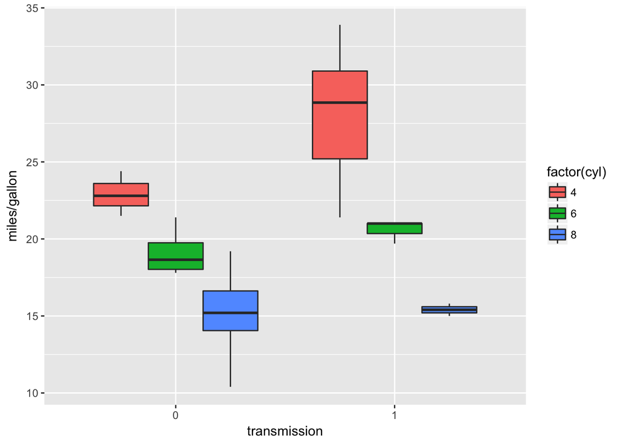

```r
g <- ggplot(data = mtcars, aes(y = mpg, x = factor(am), fill = factor(cyl)))
g <- g + geom_boxplot()
g <- g + xlab("transmission") + ylab("miles/gallon")
g
```

Fit a linear model with transmission as the only variable

```r
fit <- lm(mpg ~ am, data = mtcars)
coef <- summary(fit)$coefficients
coef
```

```
##              Estimate Std. Error   t value     Pr(>|t|)
## (Intercept) 17.147368   1.124603 15.247492 1.133983e-15
## am           7.244939   1.764422  4.106127 2.850207e-04
```

this model assumes one line through the data.

As the slope of the linear model indicates, there is a 7.2449393 increase in miles/gallon going from automatic transmission to manual.

# confidence interval

```r
confInterval <- confint(fit)
confInterval
```

```
##                2.5 %   97.5 %
## (Intercept) 14.85062 19.44411
## am           3.64151 10.84837
```

The confidence interval indicates that with a 95% confidence, there is an increase from 3.6415096 to 10.848369 miles/gallon going from automatic transmission to manual.

# weight

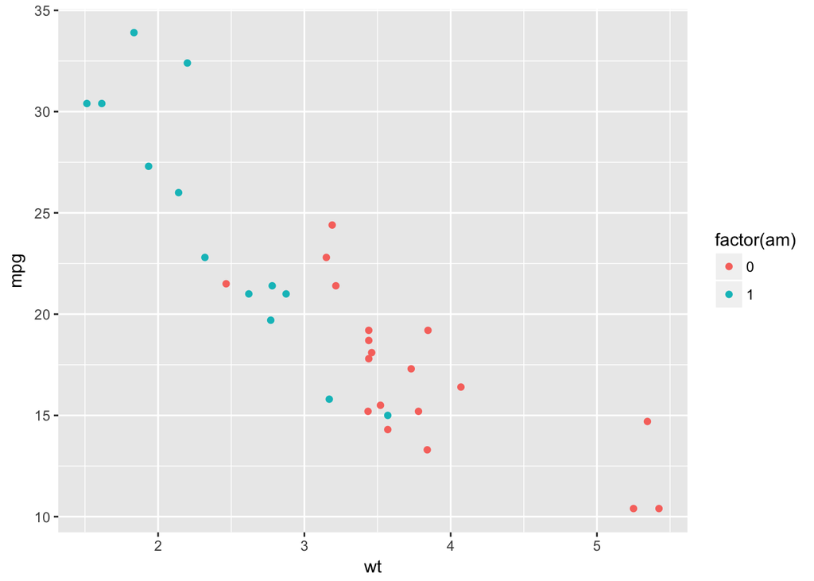

```r
g <- ggplot(data = mtcars, aes(y = mpg, x = wt, color = factor(am)))
g <- g + geom_point()
g
```

This plot indicates that weight influences the mpg outcome directly, so this is a variable worth having into account when analyzing whether automatic or manual transmission is better for mpg, given that manual cars weight less than automatic cars

```r
fit2 <- lm(mpg ~ am + wt, data = mtcars)
coef2 <- summary(fit2)$coefficients
coef2
```

```
##                Estimate Std. Error     t value     Pr(>|t|)
## (Intercept) 37.32155131  3.0546385 12.21799285 5.843477e-13
## am          -0.02361522  1.5456453 -0.01527855 9.879146e-01
## wt          -5.35281145  0.7882438 -6.79080719 1.867415e-07
```

Adding a second variable to the model, the weight of the cars, namely, wt one finds that the coefficient in front of the binary variable, am, is the change in the intercept between automatic and manual transmission. This model generates two parallel lines with different interceps and the same slope (-5.3528114), which indicates the change in mpg per unit increase (1000 lbs) in the car weight.